# Machine learning coursework

JUNYI GUAN

ID:10333271

loading the data first

```r
load("penguins.rda")
```

### Section 1:background and describe the data set

The data is on 333 penguins for 4 measured variables (bill length and depth, flipper length, weight),and also we have the data for each penguin (sex, species, islands )

In section 1,we need to found out wheather we need to split the data into different sex or not.So I using scatter plots for the data and Use different colors to represent Penguins in different sex

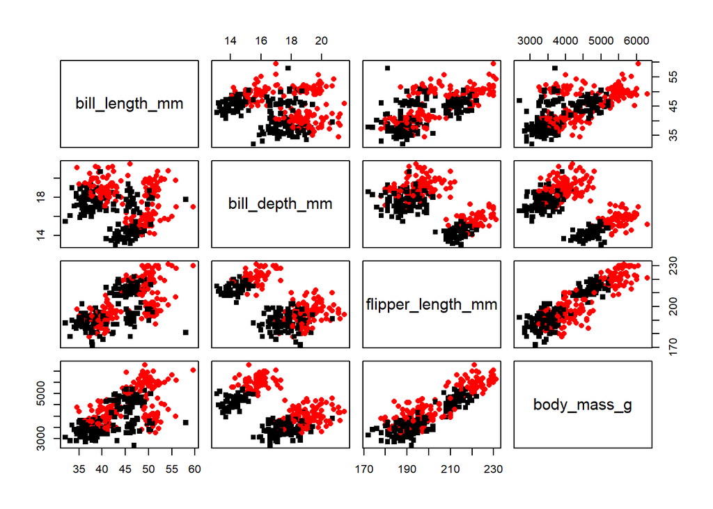

```r
pairs(X.penguins, col=as.integer(L.sex), pch=as.integer(L.sex)+14)
```

The red refer to male, black refer to female.It is clear from the scatter plots, male penguins have higher measurements than female.I decide to split the data into different sex.

### In Section 2:briefly introduce the multivariate methods you are using to analyse the data.

since the data is base on 4 variables,In order to visualize the data well, I decide to reduce 4 dimension to 2 by just using pc1 and pc2.It is clear from the summary below the first two PCs capture 88.09% of total variation

```r
S.penguins = scale((X.penguins[, 1:4]), scale=TRUE) # center and standardise
pca.out = prcomp(S.penguins)
summary(pca.out)
```

```
## Importance of components:
##                           PC1    PC2     PC3     PC4
## Standard deviation     1.6569 0.8821 0.60716 0.32846
## Proportion of Variance 0.6863 0.1945 0.09216 0.02697
## Cumulative Proportion  0.6863 0.8809 0.97303 1.00000
```

```r
x.penguins = pca.out$x[,1:2]
x.male = x.penguins[L.sex == "male",]
x.female = x.penguins[L.sex == "female",]
```

#### K-means

First,I choose different K(1,2,3…10) for K-means method to male and female data.Second ,I polt total within-group sum of squares and the between-group sum of squares vs different number of groups.

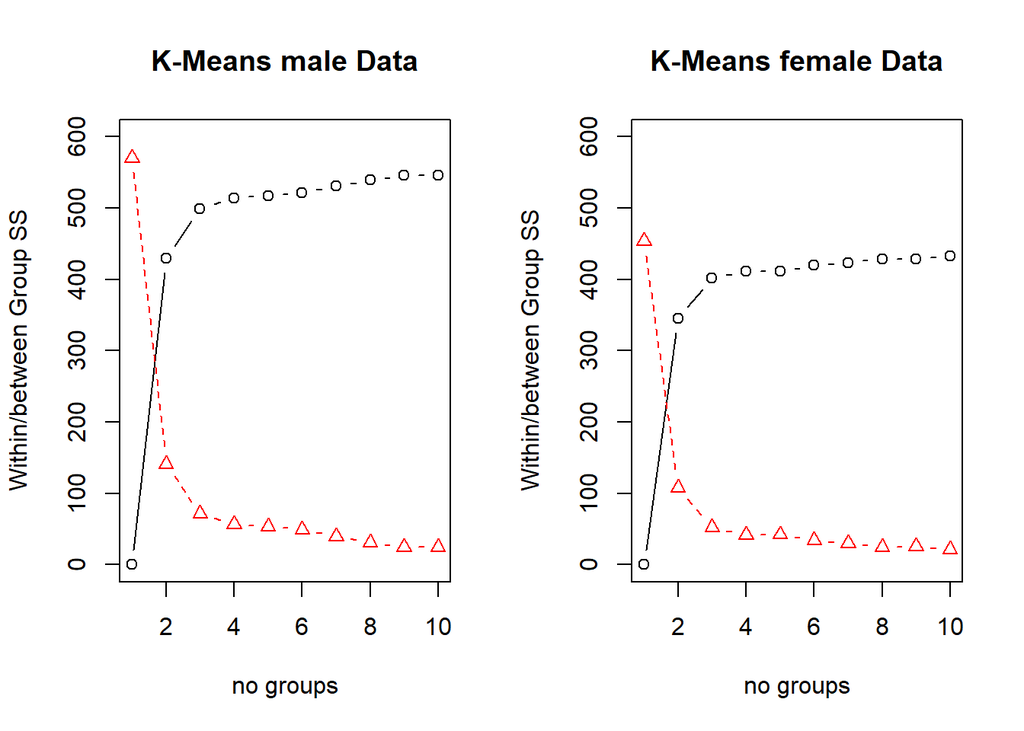

```r
kmax=10
bvec.male=numeric(kmax)
wvec.male=numeric(kmax)

bvec.female=numeric(kmax)
wvec.female=numeric(kmax)
for (k in 1:kmax)
{
  kmeans.outm = kmeans(x.male, k)
  bvec.male[k] = kmeans.outm$betweenss
  wvec.male[k] = kmeans.outm$tot.withinss
  kmeans.outf = kmeans(x.female, k)
  bvec.female[k] = kmeans.outf$betweenss
  wvec.female[k] = kmeans.outf$tot.withinss

}

par(mfcol=c(1,2))
plot(1:kmax, bvec.male, type="b", ylim=c(0, 600), xlab="no groups",
     ylab="Within/between Group SS", main="K-Means male Data")
points(1:kmax, wvec.male, type="b", col=2, lty="dashed", pch=2)
plot(1:kmax, bvec.female, type="b", ylim=c(0, 600), xlab="no groups",
     ylab="Within/between Group SS", main="K-Means female Data")
points(1:kmax, wvec.female, type="b", col=2, lty="dashed", pch=2)
```

It is clear that the optimal value for K is equal to 3,because between grop variation do not increase a lot if We still increase the number of clusters(k).

So I decide to choose K=3 to run K-means algorism.

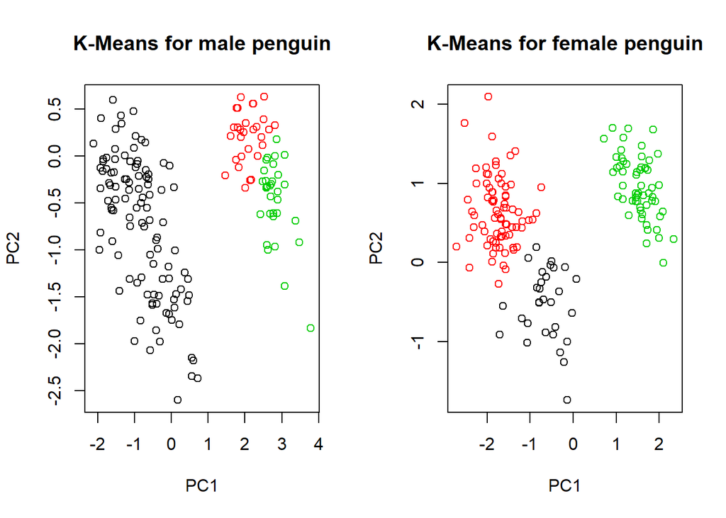

```r
par(mfcol=c(1,2))
kmeans.out3m = kmeans(x.male, 3)
plot(x.male, col=kmeans.out3m$cluster, main="K-Means for male penguin")
kmeans.out3f = kmeans(x.female, 3)
plot(x.female, col=kmeans.out3f$cluster, main="K-Means for female penguin")
```

#### Gaussian mixture models

```r
library("mclust")
```

I use the original data set(4 variables)s (not the pc1 and pc2 in this question because I am affarid just using just 2 pc will influence the result). I run GMM for (1,2,3…6) six differnt clusters and plot number of classes vs BIC

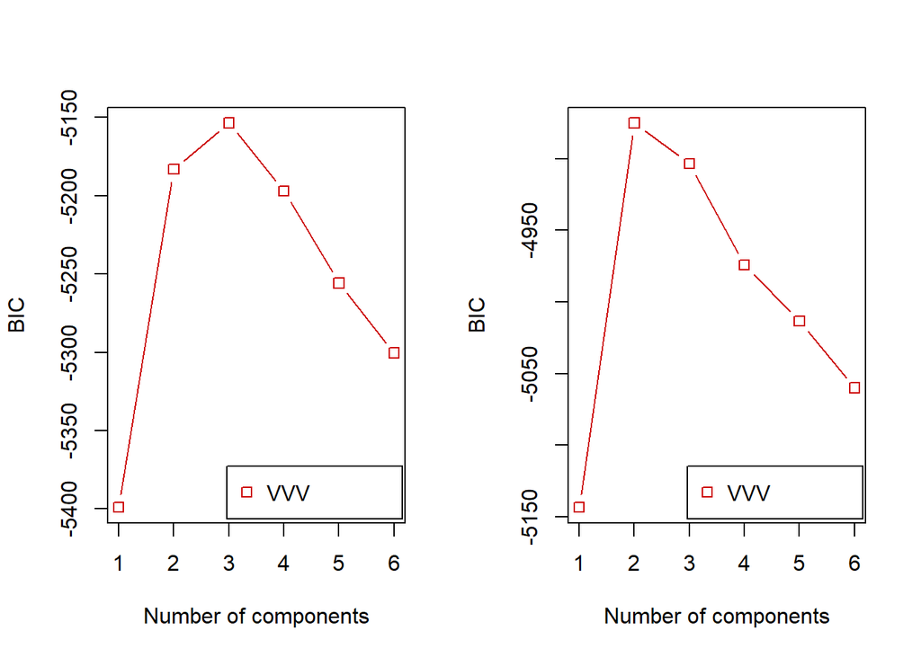

```r
par(mfcol=c(1,2))
X.male = X.penguins[L.sex == "male",]
X.female = X.penguins[L.sex == "female",]
gmm.optm = Mclust(X.male, G=1:6, verbose=FALSE,main="male penguin")
gmm.optf = Mclust(X.female, G=1:6, verbose=FALSE,main="female penguin")
plot(gmm.optm, what="BIC",modelNames="VVV")
plot(gmm.optf, what="BIC",modelNames="VVV")
```

The 2 plots show,The optimal number of cluster is 3 for male and 2 for female,according to the smallest BIC (highest BIC in R) to choose the optimal number.but 3 is also good in female.So I decide to choose K=3 to run GMM.

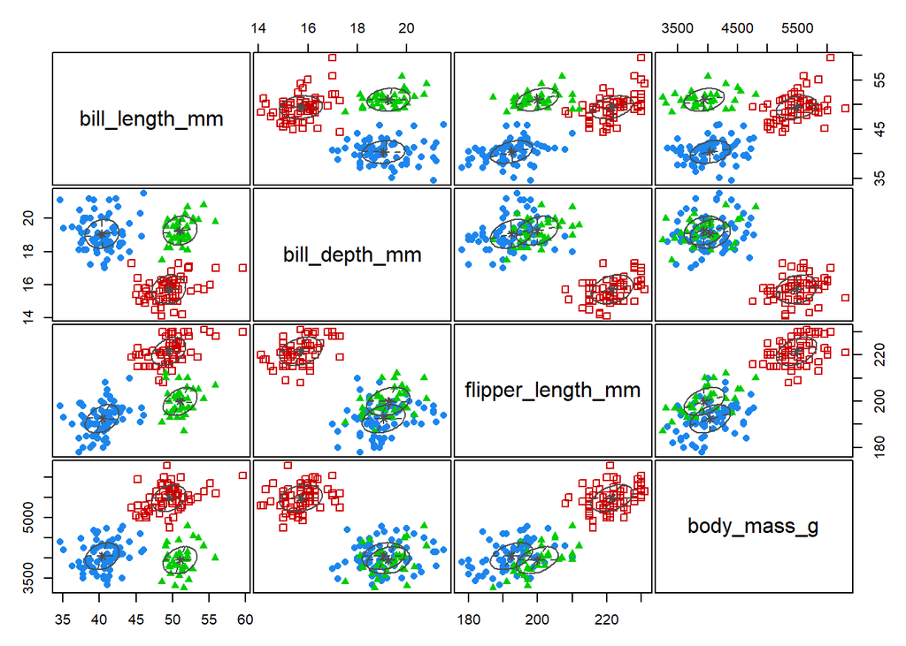

```r
par(mfcol=c(1,2))
plot(gmm.optm, what="classification")
```

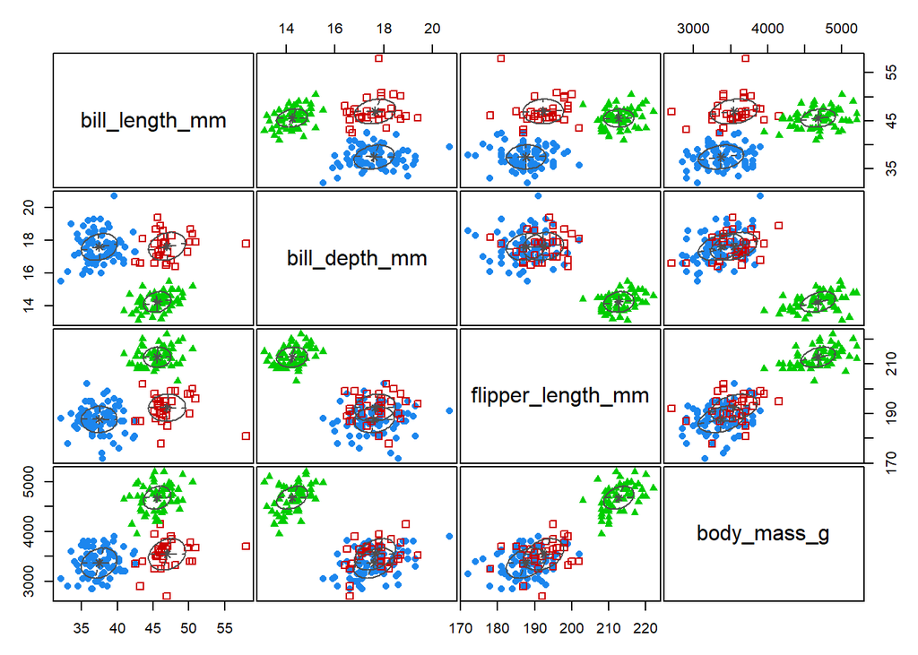

```r
plot(gmm.optf, what="classification")
```

#### In Section 3:Compare with the known clusters given by the labels L.species and L.island.

```r
#split the islands and species data into male and female
L.species.male = L.species[L.sex == "male"]
L.species.female = L.species[L.sex == "female"]
L.islands.male = L.islands[L.sex == "male"]
L.islands.female = L.islands[L.sex == "female"]
```

First analysis L.species and compare the GMM and K-means

L.species Male

```r
table(L.species.male, kmeans.out3m$cluster)
```

```
##
## L.species.male  1  2  3
##      Adelie    73  0  0
##      Chinstrap 34  0  0
##      Gentoo     0 29 32
```

```r
table(L.species.male, gmm.optm$classification)
```

```
##
## L.species.male  1  2  3
##      Adelie    73  0  0
##      Chinstrap  0  0 34
##      Gentoo     0 61  0
```

L.species Female

```r
table(L.species.female, kmeans.out3f$cluster)
```

```
##
## L.species.female  1  2  3
##        Adelie     1 72  0
##        Chinstrap 29  5  0
##        Gentoo     0  0 58
```

```r
table(L.species.female, gmm.optf$classification)
```

```
##
## L.species.female  1  2  3
##        Adelie    73  0  0
##        Chinstrap  3 31  0
##        Gentoo     0  0 58
```

L.islands Male

```r
table(L.islands.male, kmeans.out3m$cluster)
```

```
##
## L.islands.male  1  2  3
##      Biscoe    22 29 32
##      Dream     62  0  0
##      Torgersen 23  0  0
```

```r
table(L.islands.male, gmm.optm$classification)
```

```
##
## L.islands.male  1  2  3
##      Biscoe    22 61  0
##      Dream     28  0 34
##      Torgersen 23  0  0
```

L.islands Female

```r
table(L.islands.female, kmeans.out3f$cluster)
```

```
##
## L.islands.female  1  2  3
##        Biscoe     1 21 58
##        Dream     29 32  0
##        Torgersen  0 24  0
```

```r
table(L.islands.female, gmm.optf$classification)
```

```
##
## L.islands.female  1  2  3
##        Biscoe    22  0 58
##        Dream     30 31  0
##        Torgersen 24  0  0
```

The result of L.islands.male are Biscoe(83),Dream(62), Torgersen(23), and L.islands.female are Biscoe(80),Dream(61), Torgersen(24).GMM and K-means both have a lot misclassifications.But It is clear that 61 male penguins and 58 female penguins from Biscoe form a individual grop.

The remainding two clusters have penguins are not always from just one island,that is a bad result.The reason in my opinion is that there are more than 1 species live in these 2 islands since the differnt between species is obvious,It is impossible the clustering result is the 2 islands ,otherwise the variation within groups is too large!